# Asbury University (Wilmore, KY)

### Students from US

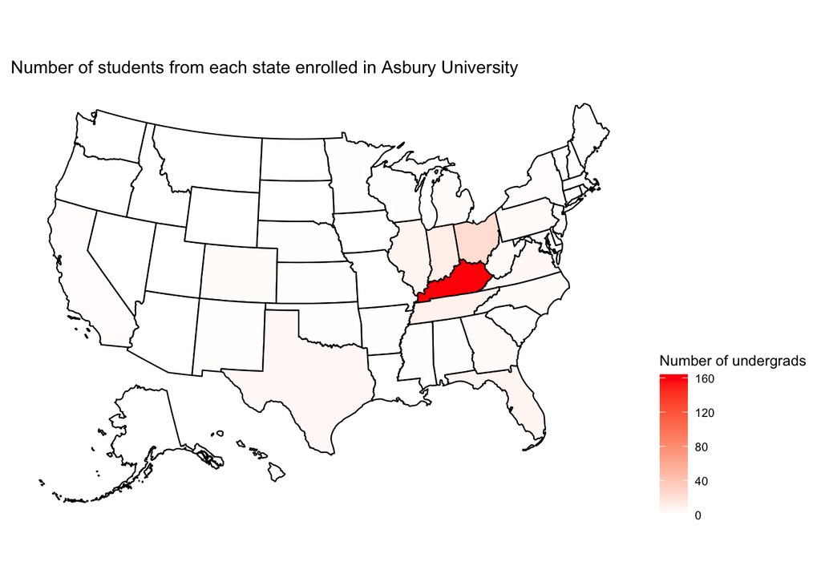

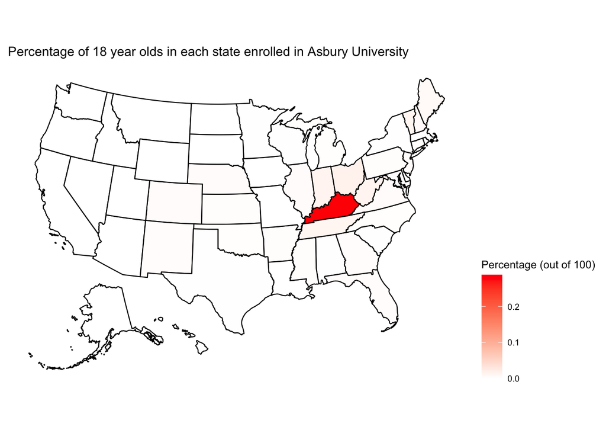